# Lab_8

Mark Chafin

3/15/2021

# 1

Download the cleansed weblog analytics data file “weblog_clean.jsonl” and read it into R (2pts). Note: The data file is in the format of JSON Lines. You should load “jsonlite” package and call stream_in() function to stream JSON input: library(jsonlite) weblog <- stream_in(file(“weblog_clean.jsonlines”))

```r
library(dplyr)
library(jsonlite)
weblog <- stream_in(file("weblog_clean.jsonlines"))
```

```
## opening file input connection.
```

[output not shown]

[output cut: 212 more lines]

[output not shown]

```
## closing file input connection.
```

# 2

Show the structure of the dataset.

```r
str(weblog)
```

```
## 'data.frame':    132258 obs. of  10 variables:
##  $ remote.host     : chr  "65.55.147.227" "65.55.86.34" "148.188.55.88" "72.30.57.238" ...
##  $ request.datetime: chr  "2009-10-15 02:00:24" "2009-10-15 02:00:58" "2009-10-15 02:01:41" "2009-10-15 02:01:59" ...
##  $ weekday         : chr  "Thursday" "Thursday" "Thursday" "Thursday" ...
##  $ request.method  : chr  "GET" "GET" "GET" "GET" ...
##  $ request.uri     : chr  "index.html" "index.html" "faq.html" "contribute.txt" ...
##  $ status          : int  200 200 200 200 200 200 200 200 200 200 ...
##  $ response.size   : int  21878 1416 10946 39943 17247 7883 18119 10946 1416 37122 ...
##  $ IP_number       : num  1.09e+09 1.09e+09 2.50e+09 1.21e+09 1.12e+09 ...
##  $ country_code    : chr  "US" "US" "US" "US" ...
##  $ country_name    : chr  "United States" "United States" "United States" "United States" ...
```

# 3

Change the data type of “request.datetime” as POSIXct by using the as.POSIXct() function (2 pts).

```r
weblog$request.datetime <- as.POSIXct(weblog$request.datetime, format = "%Y-%m-%d %H:%M:%S")
```

# 4

Show summary statistics of the dataset.

```r
summary(weblog)
```

```
##  remote.host        request.datetime                weekday
##  Length:132258      Min.   :2009-10-15 02:00:24   Length:132258
##  Class :character   1st Qu.:2009-10-16 16:15:42   Class :character
##  Mode  :character   Median :2009-10-18 22:55:37   Mode  :character
##                     Mean   :2009-10-18 18:36:35
##                     3rd Qu.:2009-10-20 16:23:04
##                     Max.   :2009-10-22 01:59:36
##  request.method     request.uri            status      response.size
##  Length:132258      Length:132258      Min.   :200.0   Min.   :       15
##  Class :character   Class :character   1st Qu.:200.0   1st Qu.:     1590
##  Mode  :character   Mode  :character   Median :200.0   Median :    11489
##                                        Mean   :202.8   Mean   :  1002980
##                                        3rd Qu.:200.0   3rd Qu.:    23574
##                                        Max.   :416.0   Max.   :217164050
##    IP_number         country_code       country_name
##  Min.   :7.222e+07   Length:132258      Length:132258
##  1st Qu.:1.210e+09   Class :character   Class :character
##  Median :1.535e+09   Mode  :character   Mode  :character
##  Mean   :1.996e+09
##  3rd Qu.:2.654e+09
##  Max.   :3.740e+09
```

# 5

Get the frequency distribution of weekday by using table() function (1 pt). Which day has the largest number of visits (1 pt)?

```r
weekday.freq <- table(weblog$weekday)
sort(weekday.freq)
```

```
##
##    Sunday  Saturday  Thursday    Monday   Tuesday    Friday Wednesday
##     12269     14981     17689     18780     20997     22014     25528
```

```r
print("Has the largest number of visits")
```

```
## [1] "Has the largest number of visits"
```

```r
weekday.freq %>% which.max()
```

```
## Wednesday
##         7
```

# 6

Cross tabulate weekday and request.uri (1 pt)(refer to the two-way frequency table on slide 17 of Chapter 5). How many visits of the “faq.html” page on Fridays (1 pt)?

```r
cross_tabulate <- table(weblog$weekday, weblog$request.uri)
cross_tabulate
```

```
##
##             contribute.txt faq.html index.html robots.txt somefile.zip
##   Friday              6534     4407       8806        111         2156
##   Monday              5541     3650       7564        112         1913
##   Saturday            4448     2934       5976        102         1521
##   Sunday              3532     2535       4900         94         1208
##   Thursday            5265     3515       7063        107         1739
##   Tuesday             6168     4183       8443        100         2103
##   Wednesday           7697     5173      10027         97         2534
```

```r
print("There are 4407 visits on the faq.html page on Friday")
```

```
## [1] "There are 4407 visits on the faq.html page on Friday"
```

# 7

Draw a bar plot to show the distribution of visits by weekday (2 pts).

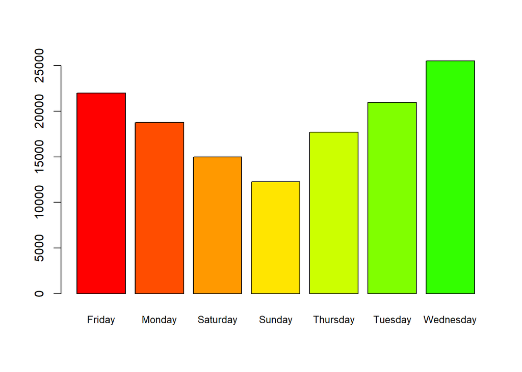

```r
weblog.barplot <- table(weblog$weekday)
barplot(weblog.barplot, col = rainbow(20), cex.names = .8)
```

# 8

Draw a stacked bar plot to show the distribution of visits by request.uri and request.method (use request.method to group visits) (2 pts).

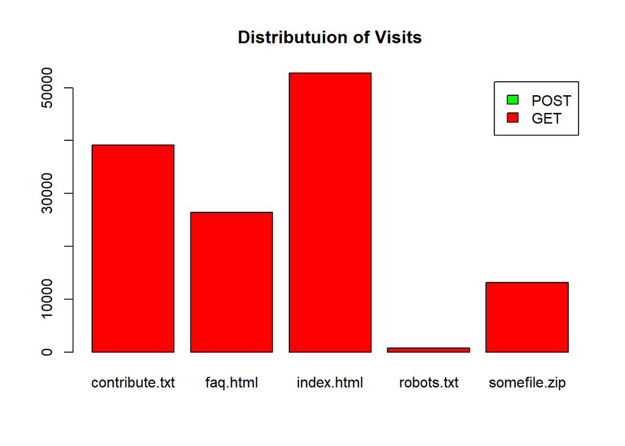

```r
weblog.stacked <- table(weblog$request.method, weblog$request.uri)
barplot(weblog.stacked,
        main = "Distributuion of Visits",
        col = rainbow(3),
        legend = rownames(weblog.stacked))
```

# 9

Draw a pie chart to present the distribution of visits by request.uri and show the count of visits for each URI (2 pts).

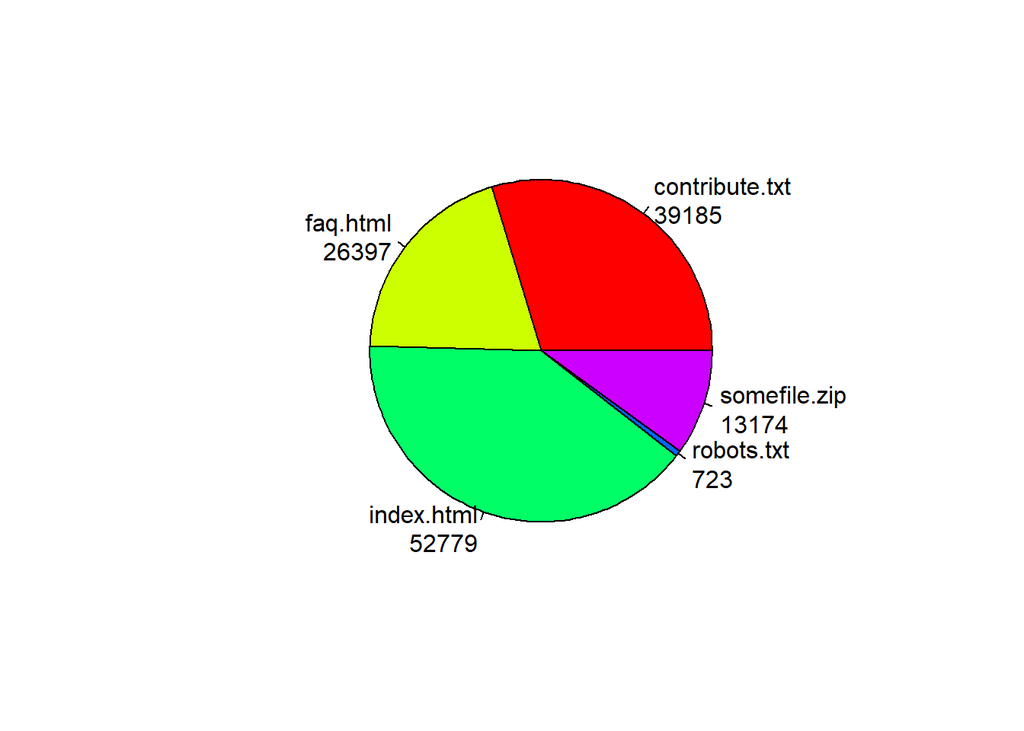

```r
weblog.piechart <- table(weblog$request.uri)
labels <- paste(names(weblog.piechart),"\n", weblog.piechart, sep = "")
pie(weblog.piechart, labels = labels, col = rainbow(5))
```

# 10

Draw a pie chart to present the distribution of visits by request.uri and how the percentage of visits for each URI (2 pts).

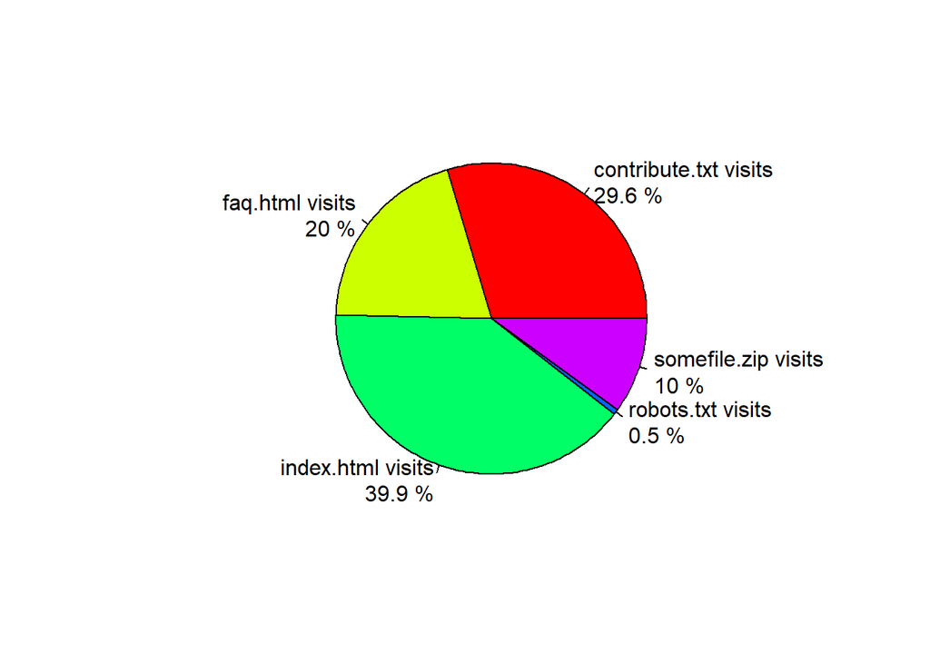

```r
piechart <- round(weblog.piechart/sum(weblog.piechart)*100, digits = 1)
label2 <- paste(names(weblog.piechart), " visits\n", paste(piechart,"%"), sep="")
pie(piechart,
    labels = label2,
    col=rainbow(length(label2)))
```

# 11

Calculate 5-number summary for reponse.size by using quantile() function (2 pts).

```r
quantile(weblog$response.size)
```

```
##        0%       25%       50%       75%      100%
##        15      1590     11489     23574 217164050
```